# ggplo2 Basics

### Background

`ggplot2` is one of the most widely used packages in all of `R`! It was created by Hadley Wickham, a very well-known data scientist and deevloper. Check out his site here, http://hadley.nz/. Once there, take a look around and even check out some of the other amazing packages he’s created! Some of these include: `tidyr`, `dplyr`, `stringr`, and many more! Some of these we’re going to talk about in depth in other tutorials, but for now, back to `ggplot2`!

### Why ggplot2?

Although base *R* comes with solid visualizations capabilities, it’s really hard to beat what `ggplot2` brings to the table. Not only is using `ggplot2` extremely straightforward (after some practice), but the end result is almost always more aesthetically pleasing than what could be produced through base *R* graphics. Before I explain more about `ggplot2`, let’s look at a graphic made using it.

Here’s one using the `diamonds` dataset that comes with `ggplot2`:

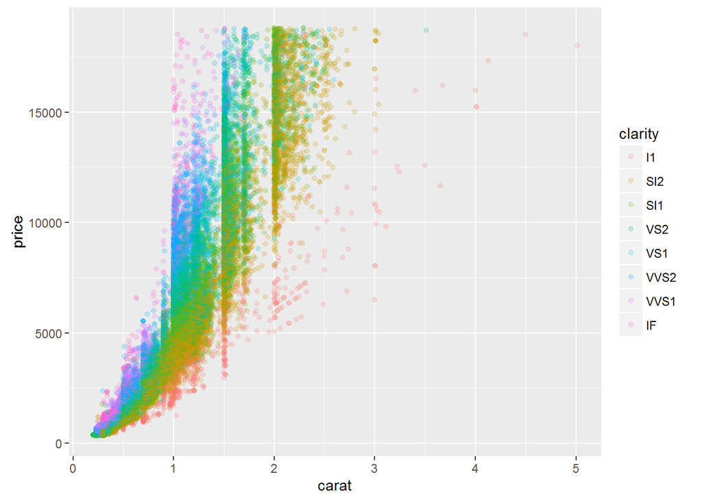

Although there is a lot going on in this visualization, we can see clearly an exponential increase in the `price` of a diamond based on its `carat` size. However, this graphic extends this analysis one step further and provides a color representation for each `clarity` classification. Using this additional layer, we can see that some depending on the `clarity` classification, the price of a diamond increases faster based on changes in the `carat` size.

Okay, so this graphic is pretty cool, but it’s also extremely basic. In fact, it only took one line of code to make:

```r
ggplot(diamonds, aes(x = carat, y = price, col = clarity)) + geom_point(alpha = .2)
```

This is your first glimpse at what the syntax for a `ggplot2` visualization looks like. Don’t worry about what’s actually happening here, just notice how simple it was to create the above plot. But what makes `ggplot2` so simple? When creating the package, Hadley Wickham decided to build it upon the foundations of the grammar of graphics. Before we can truly understand the power and simplicity of `ggplot2`, we must understand the basics of the grammar of graphics; which is where the *gg* in `ggplot2` comes from. Check out the next section to learn more!